# Parcial5

## Distribución conjunta de Sexo y División

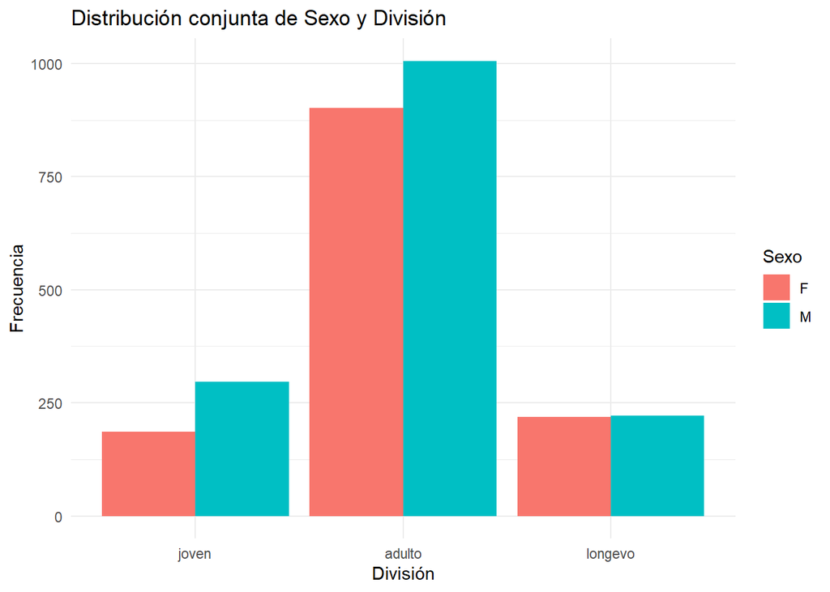

En la División Longevo, se observa una distribución equilibrada entre moluscos femeninos y masculinos, indicando una representación equitativa de ambos sexos. La División Adulto presenta la mayor cantidad de población, con una alta presencia tanto de moluscos femeninos como masculinos, lo que sugiere que esta etapa concentra el grueso de la muestra. En cambio, en la División Joven, se evidencia una mayor proporción de machos en comparación con hembras, lo que podría indicar un sesgo de sexo en esta etapa o una diferencia en la dinámica poblacional juvenil.

## **Correlacion**

Antes de realizar el analisis factorial para datos mixtos, debemos comprobar que las variables numericas sean interdependientes, aunque esto no es necesario, nuestro trabajo considera que es importante mostrar la correlacion existente.Esto lo haremos solo mediante una grafica

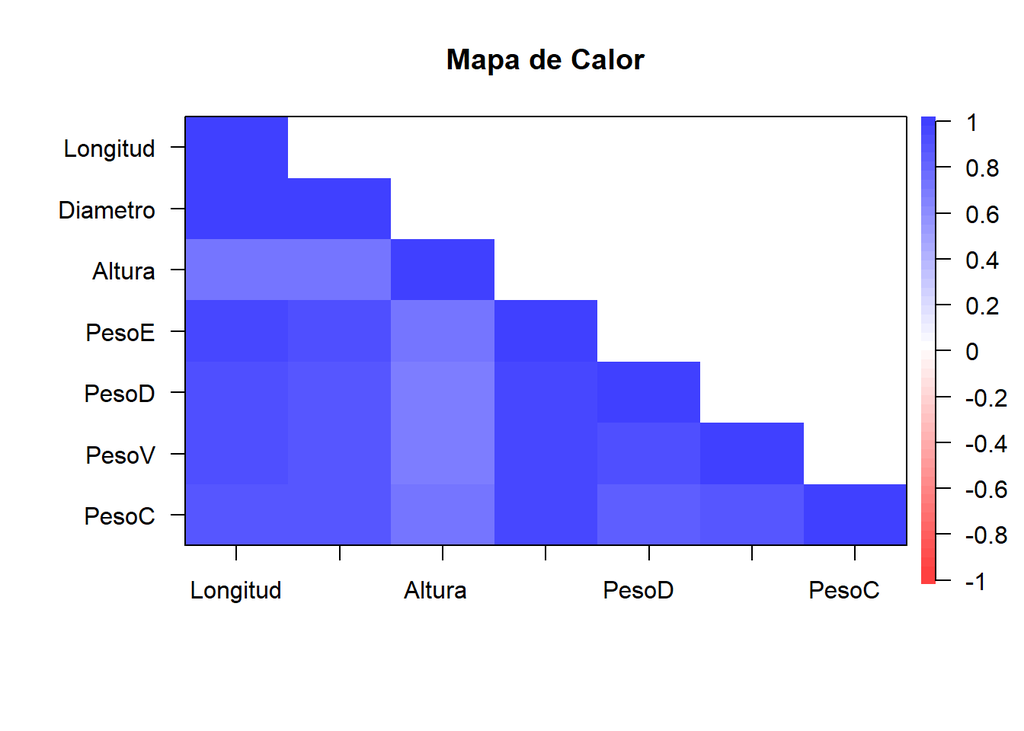

Como se puede observar las variables numericas estan fuertemente correlacionadas de forma positiva